# Markdown

# Hello, Markdown!

Use marimo’s “`md`” function to embed rich text into your marimo apps. This function compiles Markdown into HTML that marimo can display.

For example, here’s the code that rendered the above title and paragraph:

```python
mo.md(
    '''
    # Hello, Markdown!

    Use marimo's "`md`" function to embed rich text into your marimo
    apps. This function compiles your Markdown into HTML that marimo
    can display.
    '''
)
```

## LaTeX

You can embed LaTeX in Markdown.

For example,

```python
mo.md(r'$f : \mathbf{R} \to \mathbf{R}$')
```

renders $f : \mathbf{R} \to \mathbf{R}$, while

```python
mo.md(
    r'''
    \[
    f: \mathbf{R} \to \mathbf{R}
    \]
    '''
)
```

Use `r''` strings to remove the need to escape backslashes when writing LaTeX.

## Interpolating Python values

You can interpolate Python values into markdown using `f-strings` and marimo’s `as_html` function. This lets you create markdown whose contents depend on data that changes at runtime.

Here are some examples.

### Plots

A matplotlib figure:

```
_x = np.linspace(start=0, stop=2*np.pi)
sine_plot = plt.plot(_x, np.sin(_x))
mo.md(f"{mo.as_html(sine_plot)}")
```

yields

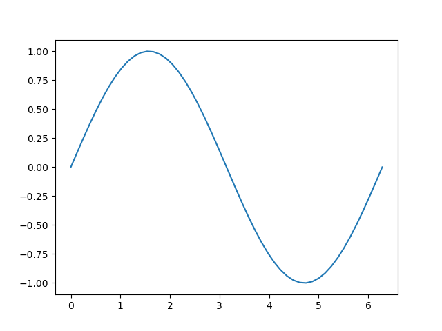

### UI elements

A `marimo.ui` object:

```
leaves = mo.ui.slider(1, 16, label="🍃: ")
mo.md(f"{leaves}")
```

marimo objects know how to format themselves, so you can omit the call to `as_html`.

### Other objects

Use `mo.as_html` to convert objects to HTML. This function generates rich HTML for many Python types, including:

- lists, dicts, and tuples,
- `pandas` dataframes and series,
- `seaborn` figures,
- `plotly` figures, and
- `altair` figures.

For example, here's a pandas dataframe:

|  | x | sin(x) |
| --- | --- | --- |
| 0 | 0.000000 | 0.000000e+00 |
| 1 | 0.698132 | 6.427876e-01 |
| 2 | 1.396263 | 9.848078e-01 |
| 3 | 2.094395 | 8.660254e-01 |
| 4 | 2.792527 | 3.420201e-01 |
| 5 | 3.490659 | -3.420201e-01 |
| 6 | 4.188790 | -8.660254e-01 |
| 7 | 4.886922 | -9.848078e-01 |
| 8 | 5.585054 | -6.427876e-01 |
| 9 | 6.283185 | -2.449294e-16 |

`mo.as_html` is only needed when interpolating objects into markdown; the last expression of a cell (its output) is converted to HTML automatically.

## Putting it all together

Here’s a more interesting example that puts together everything we’ve learned: rendering markdown with LaTeX that depends on the values of Python objects.

**A sin curve.**

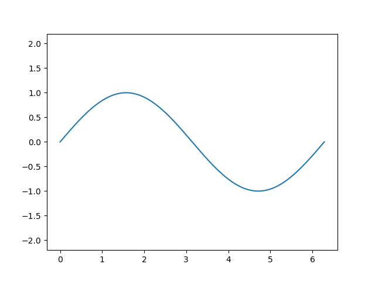

Back to top